# MATH 440: Joint Distributions

Hitchman

# Preamble: Vectors and matrices in R

At a glance.

**1.** Define a vector with the `c()` command. Define a matrix with the `matrix()` command, within which we specify the entries (within the `c()` command), its shape, and whether we’re entering the entries row-wise or column-wise. Here are two vectors and a matrix

```r
v = c(1,2,3)
w = c(0,-2,1)
M = matrix(c(2,3,4,1,1,0,-1,2,1),ncol=3,byrow=TRUE)
M
```

```
##      [,1] [,2] [,3]
## [1,]    2    3    4
## [2,]    1    1    0
## [3,]   -1    2    1
```

**2.** Vector addition

```r
v+w
```

```
## [1] 1 0 4
```

**3.** Scalar multiplication

```r
5*v
```

```
## [1]  5 10 15
```

**4.** Dot product

```r
v %*% w
```

```
##      [,1]
## [1,]   -1
```

**5.** The command `v*w` returns a “component-wise product” vector which can be useful.

```r
v*w
```

```
## [1]  0 -4  3
```

Note: `sum(v*w)` also returns the dot product

```r
sum(v*w)
```

```
## [1] -1
```

**6.** Matrix multiplication

```r
v %*% M
```

```
##      [,1] [,2] [,3]
## [1,]    1   11    7
```

What does this do?

```r
v * M
```

```
##      [,1] [,2] [,3]
## [1,]    2    3    4
## [2,]    2    2    0
## [3,]   -3    6    3
```

# Preamble: Named probability distributions in R.

The base installation of R should have included the STATS package in which common distributions can be found.

Click on the Help tab in the bottom right window of your RStudio session and search “distributions” to see a list of common probability distributions (both continuous and discrete) that come ready for use in R. All the named distributions you saw in MATH 340 should be here, including the normal distribution (`norm`), binomial (`binom`), chi square (`chisq`), the student’s t, (`t`), uniform (`unif`), and Poisson (`pois`). We associate four R commands with a built-in distribution: `dxxx`, `pxxx`, `qxxx`, and `rxxx`.

## Evaluating density functions with `dxxx`

The `dxxx` command returns the density or probability function at a particular input.

> The command `dbinom(2,5,.3)` returns the probability of $x=2$ successes in $n=5$ trials in a binomail distribution where $p = .3$ is the probability of success on each trial.
> We know from MATH 340, that for the $b(n,p)$ distribution,
> $$p(x)={n \choose x}p^x(1-p)^{n-x},$$
> so we expect `dbinom(2,5,.3)` to return
> $${5 \choose 2}(.3)^2(.7)^3,$$
> which it does:

```r
dbinom(2,5,.3)
```

```
## [1] 0.3087
```

## Cumulative probability with `pxxx`

The `pxxx` command gives the cumulative probability, so in the case of the binomial distribution above, `pbinom(2,5,.3)` will return
$$\sum_{x=0}^2 p(x)=\sum_{x=0}^2{n \choose x}p^x(1-p)^{n-x},$$

```r
pbinom(2,5,.3)
```

```
## [1] 0.83692
```

> The command `pnorm(7,10,2)` returns the proportion of the normal distribution $N(10,2)$ (mean = 10, st dev = 2) that takes a value less than 7. In other words, `pnorm(7,10,2)` returns the value of the integral
> $$\int_{-\infty}^7 f(x)~dx$$
> where $f(x)$ is the density for $N(10,2)$.

```r
pnorm(7,10,2)
```

```
## [1] 0.0668072
```

This value corresponds to the shaded area below.

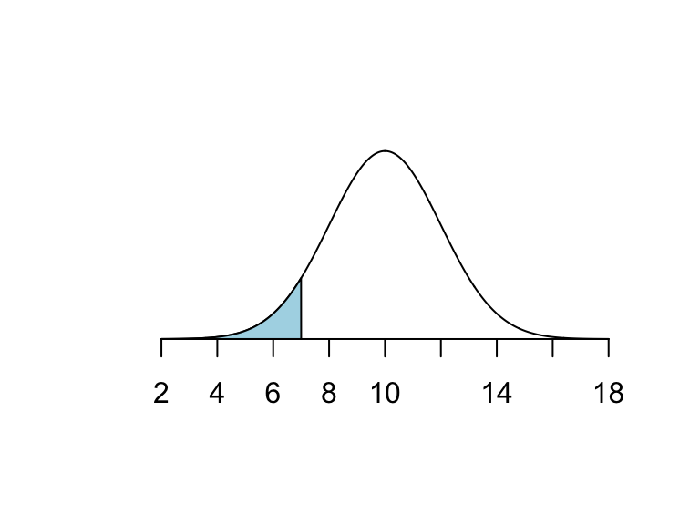

## Quantiles with `qxxx`

The `qxxx` command gives the quantile. For instance, `qnorm(.95,5,2)` returns the value in the $N(5,2)$ distribution that marks the 95th percentile: the value below which one finds 95% of the distribution:

```r
qnorm(.95,5,2)
```

```
## [1] 8.289707
```

## Random samples with `rxxx`

The `rxxx` command selects a random sample of a given size from the distribution.

> Example: The command `rpois(10,4)` will generate a random sample of size 10 drawn from a Poisson distribution with parameter $\lambda=4$. This sample is stored as a vector.

```r
rpois(10,4)
```

```
##  [1] 3 1 1 2 3 3 8 0 4 2
```

We can use `rxxx` to run simulations, and to visualize the shape of a distribution.

For a **discrete distribution** we can use `barplot()` and `table()` to tabulate the results. The `table()` command gives the total counts for each possible outcome, and the `barplot()` command applied to a table visualizes those counts.

```r
sim.data = table(rbinom(1000,10,.6)) # draw a random sample of size 1000 from the binomial distribution b(10,.6).
sim.data
```

```
##
##   0   1   2   3   4   5   6   7   8   9  10
##   1   2  10  43 116 168 270 217 120  46   7
```

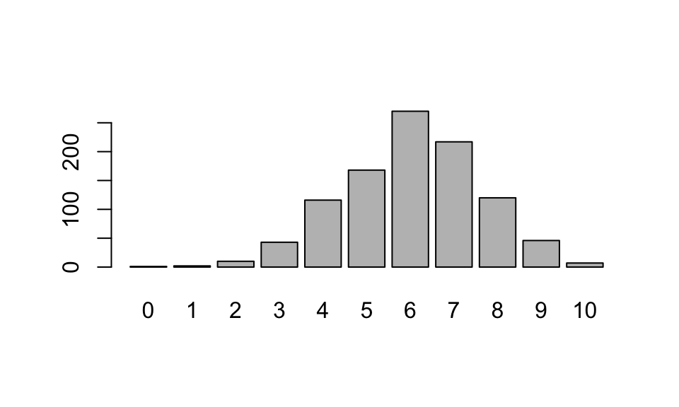

```r
barplot(sim.data)
```

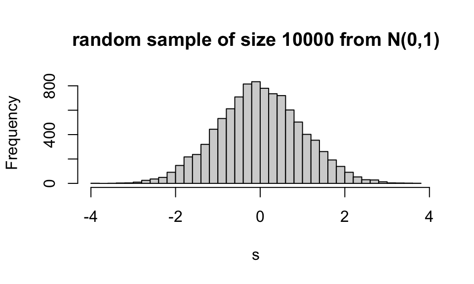

```r
s = rnorm(10000,0,1)
hist(s,breaks=35,main="random sample of size 10000 from N(0,1)")
```

# A jointly discrete distribution

In R we can input a discrete distribution in table form with the `matrix()` command. Let’s consider the 6 politicians example from class: We have 6 politicians: 2 Dems, 3 Reps, and 1 independent. We select a committee of size 2 at random from this group. Let $X$ = the number of democrats on the committee, and $Y$ = the number of Republicans on the committee. Then we worked out the joint probability function as:

| X $\setminus$ Y | 0 | 1 | 2 |
| --- | --- | --- | --- |
| 0 | 0 | 3/15 | 3/15 |
| 1 | 2/15 | 6/15 | 0 |
| 2 | 1/15 | 0 | 0 |

```r
jointpf <- matrix(
  c(0,3/15,3/15,
    2/15,6/15,0,
    1/15,0,0),
  ncol=3,byrow=T)
jointpf
```

```
##            [,1] [,2] [,3]
## [1,] 0.00000000  0.2  0.2
## [2,] 0.13333333  0.4  0.0
## [3,] 0.06666667  0.0  0.0
```

## Extracting a value from a matrix

We use jointpf[row #, col #].

The matrix `jointpf` just contains the 9 probabilities, not the values of $x$ and $y$. To extract, say `jointpf(0,2)` from this matrix we think “ok, $x = 0$ and $y = 2$, and that is entry row 1, column 3 in our matrix.” We extract this entry with the command:

```r
jointpf[1,3]
```

```
## [1] 0.2
```

## Marginal probability functions

```r
px <- rowSums(jointpf)
py <- colSums(jointpf)
```

Note: These marginal probabilities are vectors! Here’s `px`, and I’m choosing to display the values rounded to 3 decimal places:

```r
round(px,3)
```

```
## [1] 0.400 0.533 0.067
```

## Conditional probabilities

As an example, we determine $P(X=2|Y=0)$, the probability that the committee has two democrats, given it has no republicans.

```r
jointpf[3,1]/py[1]
```

```
## [1] 0.3333333
```

## Expected Value

To compute expected values we need to take the values of $x$ and $y$ into account, so we define the space of $X$ and $Y$ to align entry-wise with the joint probability table:

```r
x <- c(0,1,2)
y <- c(0,1,2)
```

We can evaluate
$$E[X]=\sum_{\text{all }x} x \cdot p(x)$$
in two ways.

```r
sum(x*px)
```

```
## [1] 0.6666667
```

Or, we can use the dot product command (`%*%`)

```r
x%*%px
```

```
##           [,1]
## [1,] 0.6666667
```

Here we evaluate and label some useful quantities. Can you identify them all?

```r
EX <- sum(px*x)
EY <- sum(py*y)
EX2 <- sum(px*x^2)
EY2 <- sum(py*y^2)
VX <- EX2-(EX)^2
VY <- EY2-(EY)^2
```

## Covariance

Recall that
$$\text{Cov}(X,Y)=E[XY]-\mu_X\mu_Y,$$
and
$$E[XY] = \sum_{x=0}^2\sum_{y=0}^2 xy\cdot p(x,y).$$
We can compute this expected value by brute force:

```r
sum=0
for (i in 0:2){
  for (j in 0:2){
    sum=sum+i*j*jointpf[i+1,j+1] # remember row and column numbers in the matrix run from 1 to 3
  }
}
EXY <- sum
EXY
```

```
## [1] 0.4
```

Note that `EXY`= 0.4, something we could have done quickly by hand since there is just one non-zero term in the sum defining this quantity. In any event,

```r
CovXY <- EXY - EX*EY
CovXY
```

```
## [1] -0.2666667
```

More efficiently, thanks to our linear algebra skills, we can find Cov$(X,Y)$ in one fell swoop:

```r
x %*% jointpf %*% y - EX * EY
```

```
##            [,1]
## [1,] -0.2666667
```

And the correlation coefficient is

```r
rhoXY <- CovXY/(sqrt(VX*VY))
rhoXY
```

```
## [1] -0.7071068
```

Clearly these variables are negatively associated! As the number of democrats on the committee increases, the number of republicans on the committe tends to decrease.